# CRO-USD

## CRO-USD today is +0300, 2025-07-29, 17:36:44

This crypto forecast was generated by gemini-2.0-flash API

## Daily Chart

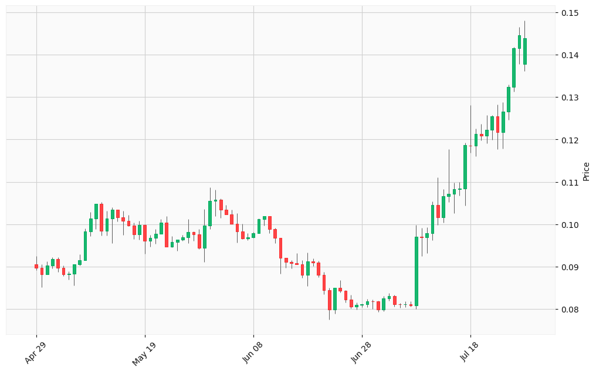

## Hourly Chart

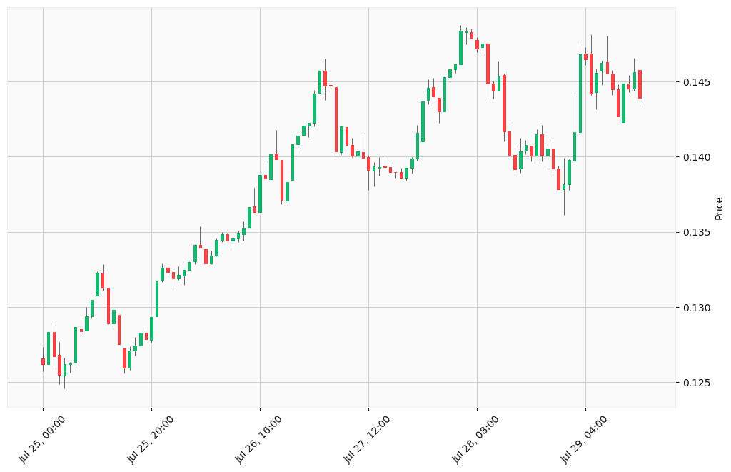

Okay, I will analyze the provided CRO-USD cryptocurrency data, incorporate external market information, and generate trading signals based on your instructions.

First, I will define some functions to perform technical analysis. Then, I’ll use the `google_search` tool to gather current information that might affect the CRO-USD market. Finally, I’ll combine technical analysis of the provided data with the insights gleaned from the web searches to formulate buy/sell signals, complete with confidence levels and justifications.

Okay, I have the search results. Here’s a summary of the relevant information:

- **General Sentiment:** The overall sentiment around CRO appears positive, with many sources indicating a “buy” or “strong buy” signal.
- **Recent News:** CRO is up recently due to a partnership between Crypto.com and Theta Network. It has also benefited from being included in a “Crypto Blue Chip” ETF.
- **Technical Analysis:** Technical indicators lean toward a buy signal. The RSI (Relative Strength Index) is high, indicating overbought conditions, but momentum is still bullish. The MACD (Moving Average Convergence Divergence) also indicates bullish momentum.
- **Price Prediction:** Some sources suggest CRO could reach $0.17 soon and potentially $0.20.
- **Market Factors**: Rising Open Interest (OI) and a long-to-short ratio above 1 suggest increasing bullish sentiment and new money entering the CRO market.

Now, let’s analyze the provided OHLCV data and generate trading signals.

**Analysis of Provided Data**

First, let’s calculate some simple moving averages (SMA) for the daily chart to identify trends. I will calculate the 7-day and 30-day SMAs. Also I will calculate the Relative Strength Index (RSI) for the daily chart.

```python
import numpy as np

daily_data = np.array([
    [0.090539, 0.092563, 0.08923, 0.089678, 24454375],
    [0.089678, 0.090498, 0.085151, 0.088231, 23574895],
    [0.088233, 0.091224, 0.08823, 0.090283, 26753541],
    [0.090284, 0.092158, 0.089647, 0.091851, 25854884],
    [0.091851, 0.092211, 0.08882, 0.089778, 20896895],
    [0.089778, 0.090325, 0.087793, 0.088232, 17702163],
    [0.088232, 0.08888, 0.086888, 0.088357, 20152394],
    [0.088357, 0.09052, 0.085592, 0.090516, 22466648],
    [0.09051, 0.092963, 0.090253, 0.09146, 27251611],
    [0.09146, 0.09894, 0.091457, 0.098308, 41739722],
    [0.098308, 0.102901, 0.097238, 0.10136, 39283969],
    [0.10136, 0.104864, 0.098839, 0.104846, 41111165],
    [0.104847, 0.105204, 0.097311, 0.098412, 31319420],
    [0.098402, 0.103143, 0.097317, 0.101421, 45458151],
    [0.101421, 0.103937, 0.095497, 0.103412, 46749073],
    [0.103412, 0.103502, 0.100662, 0.101661, 32274015],
    [0.101661, 0.103195, 0.097446, 0.10086, 41101078],
    [0.100861, 0.10214, 0.099555, 0.099668, 22931603],
    [0.099668, 0.10034, 0.096538, 0.09756, 21845538],
    [0.09756, 0.100786, 0.096348, 0.099798, 25782286],
    [0.099798, 0.099928, 0.093001, 0.096103, 27307536],
    [0.096103, 0.097531, 0.09474, 0.09683, 20316899],
    [0.09683, 0.098803, 0.095361, 0.097755, 26405083],
    [0.097755, 0.101252, 0.097727, 0.100321, 26213892],
    [0.10032, 0.101843, 0.09467, 0.094734, 32640991],
    [0.094734, 0.097226, 0.094575, 0.09578, 17591688],
    [0.09578, 0.096407, 0.093697, 0.096395, 20040444],
    [0.096395, 0.09749, 0.096156, 0.096952, 20852129],
    [0.096952, 0.101288, 0.095524, 0.098167, 34690830],
    [0.098167, 0.098347, 0.096043, 0.097668, 19859032],
    [0.097668, 0.098811, 0.094193, 0.094449, 24282075],
    [0.094449, 0.103623, 0.091051, 0.09968, 76729776],
    [0.09968, 0.108683, 0.098824, 0.105481, 89961144],
    [0.105492, 0.108153, 0.10196, 0.105836, 42539211],
    [0.105835, 0.106118, 0.10154, 0.103481, 26127531],
    [0.103481, 0.104598, 0.102326, 0.102371, 24342116],
    [0.102371, 0.103445, 0.100073, 0.100159, 23163707],
    [0.100159, 0.102568, 0.095658, 0.098269, 28281454],
    [0.098269, 0.100058, 0.096483, 0.096664, 18623963],
    [0.096664, 0.097942, 0.096242, 0.096948, 18210327],
    [0.096948, 0.098174, 0.09672, 0.09796, 16229137],
    [0.09796, 0.101313, 0.097908, 0.101269, 18767216],
    [0.101269, 0.10193, 0.099672, 0.101891, 19706575],
    [0.101891, 0.10192, 0.097937, 0.098909, 22346115],
    [0.098909, 0.099172, 0.095536, 0.096729, 21387549],
    [0.096729, 0.096731, 0.088294, 0.092013, 30658202],
    [0.092013, 0.092034, 0.089781, 0.091054, 14534011],
    [0.091054, 0.091468, 0.089645, 0.090895, 14963338],
    [0.090895, 0.093231, 0.090488, 0.090512, 18197996],
    [0.090507, 0.091479, 0.087324, 0.088121, 20734905],
    [0.088121, 0.093294, 0.08548, 0.091212, 28644895],
    [0.091212, 0.091877, 0.090115, 0.090953, 16981387],
    [0.090953, 0.091338, 0.08751, 0.088053, 20772469],
    [0.088053, 0.088761, 0.083443, 0.084466, 17646289],
    [0.084466, 0.085049, 0.077559, 0.079883, 26985214],
    [0.079883, 0.084989, 0.078916, 0.084979, 20981854],
    [0.084979, 0.086879, 0.083841, 0.084261, 18668397],
    [0.084261, 0.084526, 0.081532, 0.082278, 18204555],
    [0.082278, 0.083319, 0.080195, 0.080536, 9002955],
    [0.080536, 0.08154, 0.079915, 0.080983, 10136440],
    [0.080983, 0.081267, 0.080392, 0.081136, 7135061],
    [0.081136, 0.082395, 0.080454, 0.081849, 9461601],
    [0.081849, 0.082253, 0.080014, 0.081807, 12774825],
    [0.081807, 0.081923, 0.079408, 0.079908, 10160789],
    [0.079908, 0.083147, 0.079444, 0.082575, 12324787],
    [0.082575, 0.083816, 0.082035, 0.083133, 14527169],
    [0.083133, 0.08339, 0.08054, 0.081127, 8700329],
    [0.081127, 0.081439, 0.080324, 0.081116, 5531058],
    [0.081116, 0.081788, 0.080392, 0.081189, 9263166],
    [0.081189, 0.081805, 0.080542, 0.08082, 10899887],
    [0.08082, 0.099785, 0.080083, 0.097032, 204292736],
    [0.097032, 0.099101, 0.092483, 0.096936, 114421979],
    [0.096936, 0.099262, 0.093182, 0.097879, 54519059],
    [0.097879, 0.105434, 0.096283, 0.104492, 55722052],
    [0.104492, 0.111078, 0.099812, 0.101661, 59170892],
    [0.101661, 0.108327, 0.100401, 0.106673, 30043312],
    [0.106673, 0.117707, 0.105228, 0.107139, 64526112],
    [0.107143, 0.10984, 0.102659, 0.108223, 32726573],
    [0.108223, 0.109919, 0.106769, 0.108447, 30239806],
    [0.108447, 0.119259, 0.104428, 0.118604, 61258998],
    [0.118582, 0.128137, 0.116832, 0.11853, 73243110],
    [0.11853, 0.122499, 0.115998, 0.121233, 34526543],
    [0.121233, 0.123592, 0.119706, 0.120815, 33176389],
    [0.120815, 0.125681, 0.119022, 0.122251, 35713195],
    [0.122251, 0.12567, 0.119969, 0.125433, 42516031],
    [0.125433, 0.128164, 0.117703, 0.121764, 44451496],
    [0.121772, 0.128743, 0.117858, 0.126587, 54188800],
    [0.126587, 0.132893, 0.124555, 0.132322, 49705696],
    [0.132322, 0.141808, 0.131297, 0.14149, 39667002],
    [0.14149, 0.146514, 0.137743, 0.144613, 43326852],
    [0.137809, 0.148055, 0.136163, 0.143889, 102758184]
])

close_prices = daily_data[:, 3]
volume = daily_data[:,4]


def calculate_sma(data, period):
    return np.convolve(data, np.ones(period), 'valid') / period

def calculate_rsi(data, period=14):
    delta = np.diff(data)
    up, down = delta.copy(), delta.copy()
    up[up < 0] = 0
    down[down > 0] = 0

    roll_up = np.mean(up[-period:])
    roll_down = -np.mean(down[-period:])
    rs = roll_up / roll_down if roll_down != 0 else 0
    rsi = 100 - (100 / (1 + rs))
    return rsi

sma_7 = calculate_sma(close_prices, 7)
sma_30 = calculate_sma(close_prices, 30)
rsi = calculate_rsi(close_prices)

print(f"7-day SMA: {sma_7[-1]:.5f}")
print(f"30-day SMA: {sma_30[-1]:.5f}")
print(f"RSI: {rsi:.2f}")
```